# Gun Violence Map App

3/24/2018

## Outline of app

People in the United States are exposed to unprecedented levels of gun violoence, including mass shootings (MS), defined as incidents with 4 or more casualties.

Borrowing from gunviolencearchive.org, I collected geo-linked MS data from 2014 - 2018. The app allows you to explore weekly and seasnal MS trends anywhere in the country over any time period within last 4 years.

Users can select one of Fatalities, Injuries or Casualties (Fatalities + Injuries). Click on popup icons to get more information about individual incidents. Raw data is provided in tables on second tab.

## Monthly Stats

Between 2014 and 2017, there were 7229 MS casualties in USA, with an injury:fatality ratio of about 3.8.

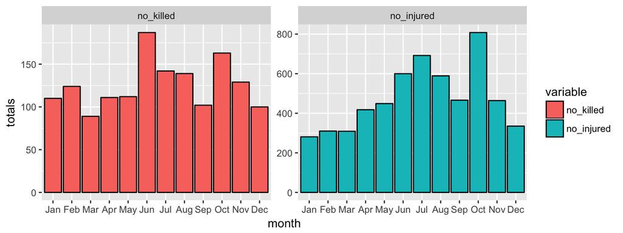

Shootings peak in warmer months. The 2017 Vegas shooting (with over 500 casualties) created an October outlier compared to overall trend. In the app you can be explore specific regions.

## Weekly Stats

Despite news of violence in schools & workplaces, many mass shootings occur on the weekend, in particular Sunday. Perhaps this can be explained by many incidencts taking place in small gatherings such as parties.

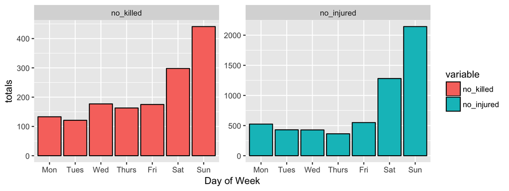

## Forecasting

Given regular seasonal MS behaviour within the USA, we can also projet future MS violence levels over the next two years:

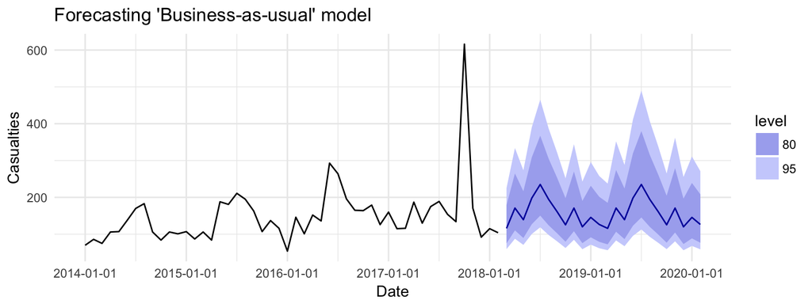

PS: Thanks for reading!